# Análisis Factorial y Análisis de Correspondencias

Representación de variables, individuos y categorías · Semana 7

Juan Sebastián Guayazán · Esteban Valente · Diego Nocua

20 de noviembre de 2026

> **Semana 7 del programa:** análisis factorial y análisis de correspondencias: representación de variables, individuos y categorías; interpretación de mapas factoriales.

**En resumen.** Con las 11 variables continuas el análisis factorial es adecuado (KMO global 0,94) y resume la información en 3 factores. Con las variables categóricas (método de proceso, color del grano y país), el análisis de correspondencias muestra asociaciones claras entre proceso y país (chi² = 416,2, p < 0,001), pero los dos primeros ejes del ACM explican una parte moderada de la inercia: es una mirada de **asociación entre categorías, no de causa**.

# Qué responde este informe

**Preguntas:** (1) ¿hay pocos factores latentes que expliquen las correlaciones entre los puntajes sensoriales? (2) ¿cómo se asocian entre sí el método de proceso, el color del grano y el país de origen?

Cada sección sigue el mismo esquema: *qué se hace y por qué*, *el resultado* y *cómo se lee*.

| Sección | Técnica | Variables | Para qué sirve |
| --- | --- | --- | --- |
| 1 | Datos | 11 continuas | Definir la base de trabajo |
| 2 | Análisis factorial (AFE) | 11 continuas | Encontrar factores latentes |
| 3 | Correspondencias simple (ACS) | Proceso × país | Asociación entre dos categorías |
| 4 | Correspondencias múltiple (ACM) | Proceso, color, país | Asociación entre varias categorías |
| 5 | ACM en detalle | Proceso, color, país | Inercia, coordenadas y contribuciones |

# 1. Datos

**Qué hacemos.** Se toma la base limpia del Coffee Quality Institute, se conservan los lotes con altitud entre 0 y 3.000 m y registros completos, y se trabaja con 11 variables continuas (los diez puntajes sensoriales sin Moisture ni defectos, más la altitud). Las variables categóricas se usan en las secciones 3 a 5.

**Resultado.** 1070 lotes y 11 variables continuas.

# 2. Análisis Factorial Exploratorio (AFE)

**Qué hacemos y por qué.** El análisis factorial busca **factores latentes** (no observables) que expliquen la correlación entre las variables. A diferencia del PCA, que resume la varianza **total**, el análisis factorial modela la varianza **compartida** entre variables (las comunalidades). Antes de ajustarlo hay que comprobar que los datos son aptos para factorizarse.

## 2.1. Prueba de adecuación muestral

El **KMO** compara las correlaciones entre pares de variables con las correlaciones parciales; valores mayores de 0,6 se consideran aceptables. La **prueba de Bartlett** contrasta si la matriz de correlaciones es distinta de la identidad (si no lo fuera, las variables no estarían relacionadas y no habría nada que resumir).

```r
# KMO: Kaiser-Meyer-Olkin — valores > 0.6 son aceptables
kmo_result <- KMO(cor(datos_t))
cat("KMO global:", round(kmo_result$MSA, 3), "\n")
```

```
## KMO global: 0.942
```

```r
# Prueba de esfericidad de Bartlett
bart <- cortest.bartlett(cor(datos_t), n=nrow(datos_t))
cat("Bartlett — chi²:", round(bart$chisq, 1), "  p-valor:", bart$p.value, "\n")
```

```
## Bartlett — chi²: 9999.2   p-valor: 0
```

**Cómo se lee.** El KMO global es 0,94: muy bueno, hay mucha correlación compartida entre las variables. Bartlett rechaza que la matriz sea la identidad (p < 0,001): las variables están correlacionadas, lo que justifica factorizar.

## 2.2. Número de factores: análisis paralelo

**Qué hacemos y por qué.** El análisis paralelo compara los valores propios de los datos con los de datos aleatorios del mismo tamaño y conserva los factores que los superan. Es una forma objetiva de elegir cuántos factores usar.

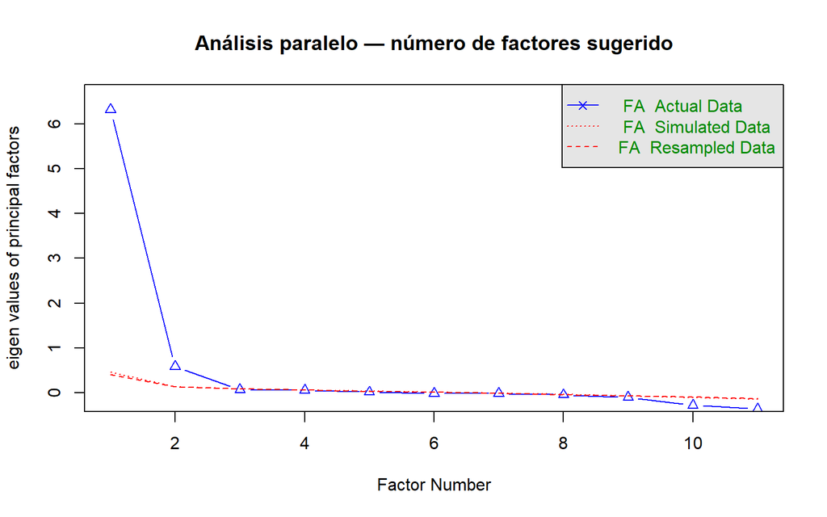

```
## Parallel analysis suggests that the number of factors =  2  and the number of components =  NA
```

```r
pa <- fa.parallel(datos_t, fm="ml", fa="fa",
            main="Análisis paralelo — número de factores sugerido")
```

**Cómo se lee.** Los factores cuyos valores propios (línea azul) quedan por encima de la línea de datos simulados son los que valen la pena. El análisis sugiere 2 factores; en el modelo se usan 3 por interpretabilidad.

## 2.3. Ajuste del modelo factorial

**Qué hacemos y por qué.** Se ajusta un modelo de 3 factores por máxima verosimilitud con rotación **Varimax**, que gira los ejes (de forma ortogonal) para que cada variable cargue fuerte en un solo factor y sea más fácil nombrar los factores.

```r
n_factores <- 3   # ajustar según análisis paralelo

modelo_fa <- fa(datos_t,
                nfactors = n_factores,
                rotate   = "varimax",  # rotación ortogonal
                fm       = "ml")       # máxima verosimilitud

print(modelo_fa$loadings, cutoff=0.3, sort=TRUE)
```

```
##
## Loadings:
##                 ML1    ML2    ML3
## Aroma            0.776  0.340
## Sabor            0.876  0.375
## Retrogusto       0.847  0.385
## Acidez           0.798  0.337
## Cuerpo           0.805  0.336
## Balance          0.819  0.368
## Puntaje.Catador  0.799  0.327
## Uniformidad             0.682
## Taza.Limpia             0.658
## Dulzura                 0.781
## Altitud
##
##                  ML1   ML2   ML3
## SS loadings    4.853 2.381 0.121
## Proportion Var 0.441 0.216 0.011
## Cumulative Var 0.441 0.658 0.669
```

```r
cat("\nComunalidades:\n")
```

```
##
## Comunalidades:
```

```r
round(modelo_fa$communality, 3)
```

```
##           Aroma           Sabor      Retrogusto          Acidez          Cuerpo
##           0.729           0.964           0.867           0.753           0.779
##         Balance     Uniformidad     Taza.Limpia         Dulzura Puntaje.Catador
##           0.829           0.531           0.481           0.639           0.746
##         Altitud
##           0.038
```

Los tres factores explican en conjunto el 66,9 % de la varianza. La **comunalidad** de una variable es la parte de su varianza que explican los factores: cerca de 1, bien representada; cerca de 0, la variable va sola (por ejemplo, la altitud, que no se relaciona con los puntajes).

## 2.4. Mapa factorial

**Qué se dibuja.** Cada variable es un punto con sus cargas en los factores 1 y 2; las flechas parten del origen. Variables cercanas en el mapa se comportan de forma parecida.

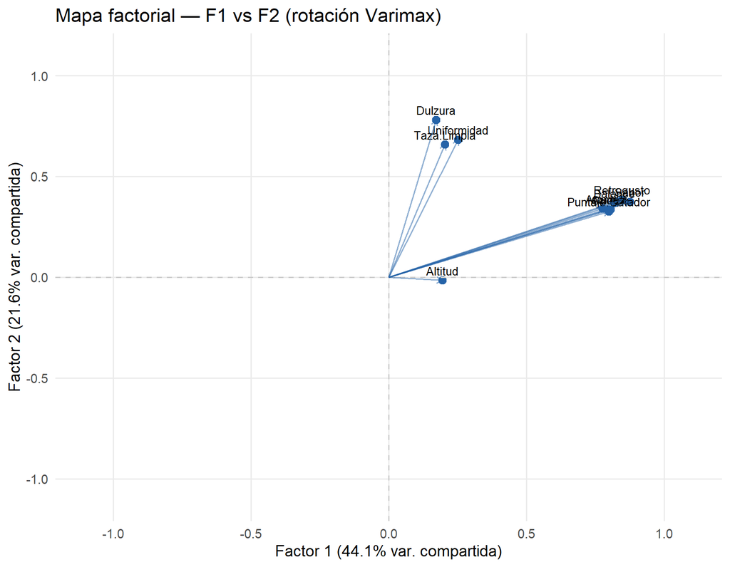

```r
cargas <- as.data.frame(unclass(modelo_fa$loadings)[, 1:2])
colnames(cargas) <- c("Factor1", "Factor2")
cargas$variable  <- rownames(cargas)

ggplot(cargas, aes(x=Factor1, y=Factor2, label=variable)) +
  geom_point(color="#2563a8", size=3) +
  geom_text(vjust=-0.6, hjust=0.5, size=3.5) +
  geom_hline(yintercept=0, linetype="dashed", color="#ccc") +
  geom_vline(xintercept=0, linetype="dashed", color="#ccc") +
  geom_segment(aes(x=0, y=0, xend=Factor1, yend=Factor2),
               arrow=arrow(length=unit(0.2,"cm")), color="#2563a8", alpha=0.5) +
  labs(title="Mapa factorial — F1 vs F2 (rotación Varimax)",
       x=paste0("Factor 1 (", round(modelo_fa$Vaccounted[2,1]*100,1), "% var. compartida)"),
       y=paste0("Factor 2 (", round(modelo_fa$Vaccounted[2,2]*100,1), "% var. compartida)")) +
  xlim(-1.1, 1.1) + ylim(-1.1, 1.1) +
  theme_minimal(base_size=14) + theme(panel.grid.minor=element_blank())
```

**Cómo se lee.** Los puntos agrupados indican variables que cargan en el mismo factor; los que quedan cerca del origen aportan poco a estos dos factores. El mapa confirma la agrupación de la tabla de cargas.

# 3. Análisis de Correspondencias Simple (ACS)

**Qué hacemos y por qué.** El ACS trabaja con **tablas de contingencia** (frecuencias cruzadas entre dos variables categóricas) y representa en un mapa conjunto la asociación entre filas y columnas. Aquí se cruzan el **método de proceso** y el **país de origen** (los 5 países con más lotes y «Otro»).

> **Importante:** el ACS no aplica a variables continuas. Requiere variables categóricas (referencia: indicación del docente).

## 3.1. Tabla de contingencia

```r
# Cruzar Processing.Method × Country.of.Origin (top 5 países)
cat_data <- data_raw %>%
  filter(!is.na(altitude_mean_meters), altitude_mean_meters > 0,
         altitude_mean_meters <= 3000,
         complete.cases(select(., all_of(vars_originales)))) %>%
  mutate(
    Proceso = ifelse(Processing.Method=="" | is.na(Processing.Method),
                     "Desconocido", Processing.Method),
    Pais    = Country.of.Origin
  )

top5 <- names(sort(table(cat_data$Pais), decreasing=TRUE)[1:5])
cat_data <- cat_data %>%
  mutate(Pais = ifelse(Pais %in% top5, Pais, "Otro"))

tabla <- table(cat_data$Proceso, cat_data$Pais)
addmargins(tabla)
```

```
##
##                             Brazil Colombia Guatemala Mexico Otro Taiwan  Sum
##   Desconocido                    7       24         5      7   33      2   78
##   Natural / Dry                 65       24         6     17   53     12  177
##   Other                          1        0         2      0   14      8   25
##   Pulped natural / honey         4        0         0      0    4      2   10
##   Semi-washed / Semi-pulped     22        0         0     14    7      9   52
##   Washed / Wet                   5      101       138    194  253     37  728
##   Sum                          104      149       151    232  364     70 1070
```

**Cómo se lee.** Cada celda cuenta los lotes con un proceso y un país. Los totales (márgenes) muestran qué procesos y países dominan la muestra: Washed / Wet es el proceso más frecuente (728 lotes) y Otro el país con más lotes (364).

## 3.2. Prueba chi² de independencia

**Qué hacemos y por qué.** Antes de mirar el mapa, se prueba si proceso y país son independientes. Si lo fueran, no habría asociación que representar.

```r
chi2 <- chisq.test(tabla)
cat("Chi² =", round(chi2$statistic, 2),
    "  gl =", chi2$parameter,
    "  p-valor =", formatC(chi2$p.value, format="e", digits=3), "\n")
```

```
## Chi² = 416.21   gl = 25   p-valor = 1.476e-72
```

```r
cat("Conclusión:", ifelse(chi2$p.value < 0.05,
    "Existe asociación significativa entre proceso y país de origen.",
    "No se rechaza independencia entre proceso y país."), "\n")
```

```
## Conclusión: Existe asociación significativa entre proceso y país de origen.
```

**Cómo se lee.** Se rechaza la independencia (chi² = 416,2, 25 g.l.). La combinación con el mayor residuo estandarizado positivo (más lotes de los esperados por azar) es **Natural / Dry en Brazil** (residuo 13,3). Con tantas celdas con pocos lotes, la aproximación chi² es solo orientativa.

## 3.3. Mapa de correspondencias

**Qué se dibuja.** Las filas (procesos, en rojo) y las columnas (países, en azul) se representan en el mismo plano. Un proceso cercano a un país indica que esa combinación es más frecuente de lo esperado; cerca del origen, un perfil promedio.

```r
ca_result <- CA(tabla, graph=FALSE)
summary(ca_result)
```

```
##
## Call:
## CA(X = tabla, graph = FALSE)
##
## The chi square of independence between the two variables is equal to 416.2134 (p-value =  1.475811e-72 ).
##
## Eigenvalues
##                        Dim.1   Dim.2   Dim.3   Dim.4   Dim.5
## Variance               0.302   0.049   0.035   0.004   0.000
## % of var.             77.537  12.571   8.954   0.932   0.005
## Cumulative % of var.  77.537  90.108  99.062  99.995 100.000
##
## Rows
##                             Iner*1000     Dim.1     ctr    cos2     Dim.2
## Desconocido               |    26.623 |   0.026   0.017   0.002 |  -0.491
## Natural / Dry             |   149.546 |   0.935  47.951   0.967 |  -0.160
## Other                     |    36.190 |   0.141   0.155   0.013 |   0.830
## Pulped natural / honey    |    16.149 |   1.199   4.458   0.833 |   0.370
## Semi-washed / Semi-pulped |    81.987 |   1.171  22.086   0.812 |   0.436
## Washed / Wet              |    78.490 |  -0.335  25.333   0.973 |   0.027
##                               ctr    cos2     Dim.3     ctr    cos2
## Desconocido                35.968   0.661 |  -0.327  22.431   0.293 |
## Natural / Dry               8.615   0.028 |   0.006   0.017   0.000 |
## Other                      32.890   0.444 |  -0.917  56.379   0.543 |
## Pulped natural / honey      2.617   0.079 |  -0.353   3.346   0.072 |
## Semi-washed / Semi-pulped  18.918   0.113 |   0.309  13.352   0.057 |
## Washed / Wet                0.991   0.006 |   0.048   4.474   0.020 |
##
## Columns
##                             Iner*1000     Dim.1     ctr    cos2     Dim.2
## Brazil                    |   243.960 |   1.575  79.985   0.989 |  -0.077
## Colombia                  |    26.192 |  -0.132   0.800   0.092 |  -0.392
## Guatemala                 |    36.648 |  -0.485  11.007   0.906 |   0.058
## Mexico                    |    32.005 |  -0.255   4.689   0.442 |   0.100
## Otro                      |    11.842 |  -0.097   1.061   0.270 |  -0.022
## Taiwan                    |    38.337 |   0.337   2.458   0.193 |   0.607
##                               ctr    cos2     Dim.3     ctr    cos2
## Brazil                      1.177   0.002 |   0.145   5.861   0.008 |
## Colombia                   43.808   0.818 |  -0.104   4.288   0.057 |
## Guatemala                   0.963   0.013 |   0.112   5.127   0.049 |
## Mexico                      4.442   0.068 |   0.264  43.349   0.472 |
## Otro                        0.335   0.014 |  -0.154  23.157   0.681 |
## Taiwan                     49.276   0.629 |  -0.311  18.217   0.166 |
```

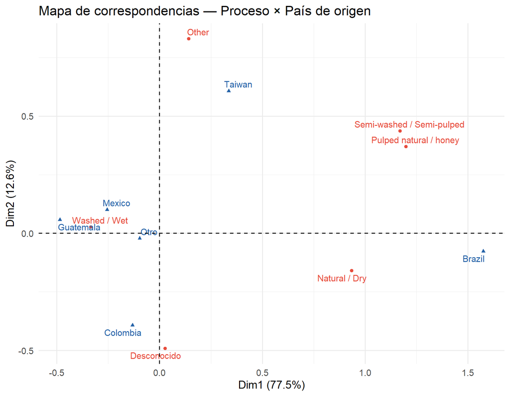

```r
fviz_ca_biplot(ca_result,
               repel   = TRUE,
               col.row = "#e74c3c",
               col.col = "#2563a8",
               title   = "Mapa de correspondencias — Proceso × País de origen") +
  theme_minimal(base_size = 14)
```

**Cómo se lee.** La primera dimensión explica el 77,5 % de la inercia y la segunda el 12,6 %. La distancia entre puntos de la misma clase (dos países, dos procesos) indica qué tan parecidos son sus perfiles; la proximidad entre un proceso y un país indica asociación. Es una asociación entre categorías, no una causa.

# 4. Análisis de Correspondencias Múltiple (ACM)

**Qué hacemos y por qué.** El ACM extiende el ACS a **más de dos variables categóricas** a la vez; equivale a hacer un ACS sobre la matriz de indicadores (dummies). Aquí se usan proceso, color del grano y país. Cada punto del mapa es una categoría; el color de los lotes indica qué tan bien representados están (cos²).

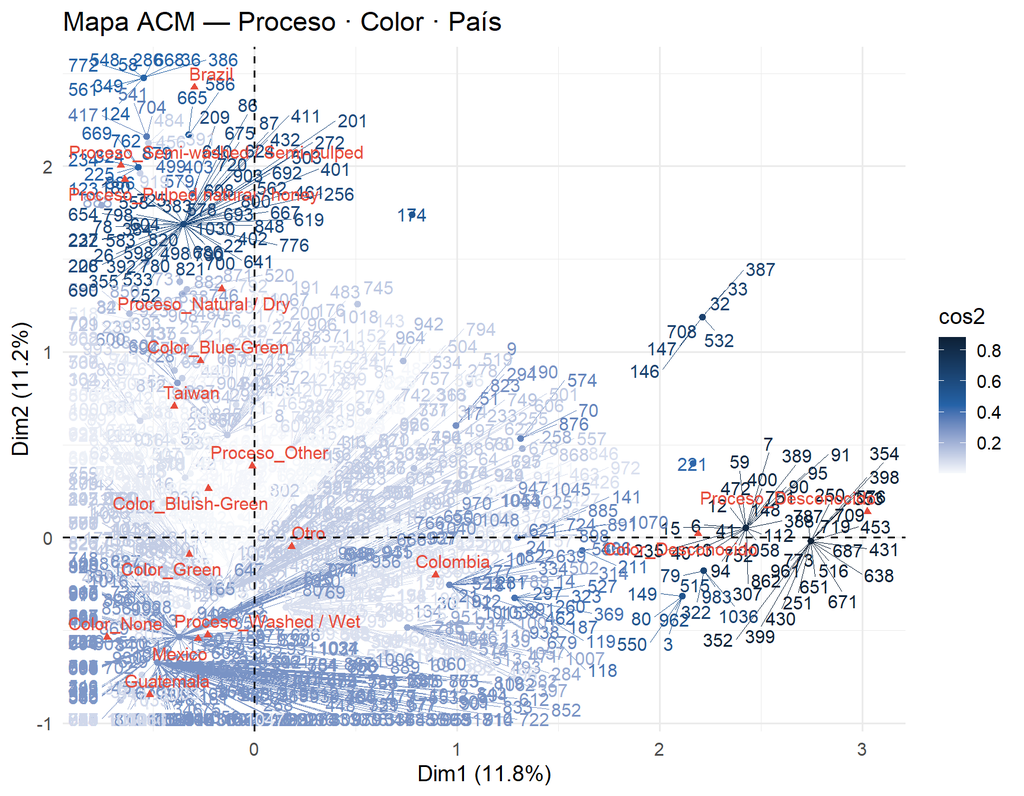

```r
# Variables categóricas: Proceso + Color + Pais
cat_df <- cat_data %>%
  mutate(Color = ifelse(Color=="" | is.na(Color), "Desconocido", Color)) %>%
  select(Proceso, Color, Pais) %>%
  mutate(across(everything(), as.factor))

mca_result <- MCA(cat_df, graph=FALSE)

fviz_mca_biplot(mca_result,
                repel       = TRUE,
                col.ind     = "cos2",
                gradient.cols = c("#f7f9fc","#2563a8","#0d2137"),
                col.var     = "#e74c3c",
                title       = "Mapa ACM — Proceso · Color · País") +
  theme_minimal(base_size = 14)
```

**Cómo se lee.** Las categorías que aparecen juntas tienden a darse en los mismos lotes. Las dos primeras dimensiones explican el 11,8 % y el 11,2 % de la inercia. En el ACM los porcentajes de inercia son bajos por construcción (hay una columna por categoría), así que no se espera que sumen mucho: se interpreta el patrón de cercanías, con cautela.

# 5. ACM en detalle

**Qué hacemos y por qué.** Se repite el ACM con las tres variables categóricas ya depuradas (valores vacíos como «Desconocido», 5 países principales y «Otro») y se revisan por separado los valores propios, las coordenadas, las contribuciones y la calidad de representación, para decidir qué dimensiones y categorías interpretar.

## 5.1. Carga y preparación de datos

```r
library(dplyr)
library(FactoMineR)
library(factoextra)
library(ggplot2)
```

```r
data_raw <- read.csv("../data/arabica_data_cleaned.csv")

cat("Registros originales:", nrow(data_raw), "\n")
```

```
## Registros originales: 1311
```

```r
datos_cat <- data_raw %>%
  dplyr::filter(
    !is.na(altitude_mean_meters),
    altitude_mean_meters > 0,
    altitude_mean_meters <= 3000
  ) %>%
  dplyr::select(
    Processing.Method,
    Color,
    Country.of.Origin
  ) %>%
  dplyr::mutate(
    dplyr::across(
      dplyr::everything(),
      ~ {
        x <- trimws(as.character(.))
        x[is.na(x) | x == ""] <- "Desconocido"
        x
      }
    )
  )

frecuencias <- sort(
  table(datos_cat$Country.of.Origin),
  decreasing = TRUE
)

top5 <- names(frecuencias)[
  seq_len(min(5, length(frecuencias)))
]

datos_cat$Country.of.Origin <- ifelse(
  datos_cat$Country.of.Origin %in% top5,
  datos_cat$Country.of.Origin,
  "Otro"
)

datos_cat <- datos_cat %>%
  dplyr::rename(
    Proceso = Processing.Method,
    Pais = Country.of.Origin
  ) %>%
  dplyr::mutate(
    dplyr::across(dplyr::everything(), as.factor)
  )

cat("Observaciones finales:", nrow(datos_cat), "\n")
```

```
## Observaciones finales: 1070
```

```r
str(datos_cat)
```

```
## 'data.frame':    1070 obs. of  3 variables:
##  $ Proceso: Factor w/ 6 levels "Desconocido",..: 6 6 1 2 6 1 1 2 2 6 ...
##  $ Color  : Factor w/ 5 levels "Blue-Green","Bluish-Green",..: 4 4 3 4 4 3 3 4 3 3 ...
##  $ Pais   : Factor w/ 6 levels "Brazil","Colombia",..: 5 5 3 5 5 5 5 5 5 5 ...
```

**Cómo se lee.** Quedan 1070 lotes con tres variables categóricas: proceso (6 niveles), color (5 niveles) y país (6 niveles).

## 5.2. Ejecución del ACM y valores propios

```r
res_mca <- FactoMineR::MCA(
  datos_cat,
  ncp = 5,
  graph = FALSE
)

print(res_mca$eig)
```

```
##        eigenvalue percentage of variance cumulative percentage of variance
## dim 1   0.5502539              11.791156                          11.79116
## dim 2   0.5248290              11.246335                          23.03749
## dim 3   0.4416781               9.464530                          32.50202
## dim 4   0.4213746               9.029455                          41.53148
## dim 5   0.3874175               8.301803                          49.83328
## dim 6   0.3585663               7.683564                          57.51684
## dim 7   0.3369916               7.221249                          64.73809
## dim 8   0.3193439               6.843084                          71.58118
## dim 9   0.2931112               6.280954                          77.86213
## dim 10  0.2659802               5.699577                          83.56171
## dim 11  0.2580842               5.530376                          89.09208
## dim 12  0.2245034               4.810787                          93.90287
## dim 13  0.1510853               3.237543                          97.14041
## dim 14  0.1334474               2.859588                         100.00000
```

```r
eig <- factoextra::get_eigenvalue(res_mca)

knitr::kable(
  round(eig, 4),
  caption = "Valores propios e inercia explicada"
)
```

Valores propios e inercia explicada

|  | eigenvalue | variance.percent | cumulative.variance.percent |
| --- | --- | --- | --- |
| Dim.1 | 0.5503 | 11.7912 | 11.7912 |
| Dim.2 | 0.5248 | 11.2463 | 23.0375 |
| Dim.3 | 0.4417 | 9.4645 | 32.5020 |
| Dim.4 | 0.4214 | 9.0295 | 41.5315 |
| Dim.5 | 0.3874 | 8.3018 | 49.8333 |
| Dim.6 | 0.3586 | 7.6836 | 57.5168 |
| Dim.7 | 0.3370 | 7.2212 | 64.7381 |
| Dim.8 | 0.3193 | 6.8431 | 71.5812 |
| Dim.9 | 0.2931 | 6.2810 | 77.8621 |
| Dim.10 | 0.2660 | 5.6996 | 83.5617 |
| Dim.11 | 0.2581 | 5.5304 | 89.0921 |
| Dim.12 | 0.2245 | 4.8108 | 93.9029 |
| Dim.13 | 0.1511 | 3.2375 | 97.1404 |
| Dim.14 | 0.1334 | 2.8596 | 100.0000 |

**Cómo se lee.** Cada dimensión tiene un valor propio (inercia) y un porcentaje de la inercia total. La primera explica el 11,8 % y la segunda el 11,2 %; juntas, 23,0 %. Es una proporción moderada: el mapa resume solo una parte de la información, así que las conclusiones deben ser prudentes. Ninguna de las dos primeras dimensiones domina: las siguientes (3, 4 y 5) aportan entre 8,3 % y 9,5 % cada una.

## 5.3. Gráfico de sedimentación

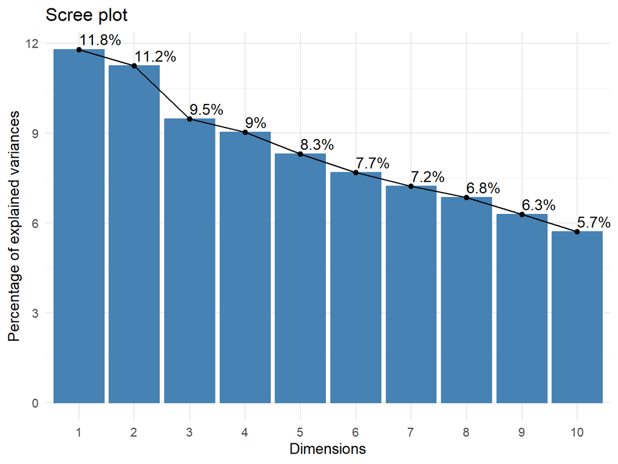

```r
factoextra::fviz_screeplot(
  res_mca,
  addlabels = TRUE
) +
  ggplot2::theme_minimal(base_size = 14)
```

**Cómo se lee.** Cada barra es el porcentaje de inercia de una dimensión. Si no hay un salto claro, la información se reparte entre varias dimensiones y no basta con las dos primeras.

## 5.4. Coordenadas, contribuciones y calidad de representación

Son tres tablas complementarias: las **coordenadas** ubican cada categoría en cada dimensión; las **contribuciones** dicen cuánto aporta cada categoría a la construcción de una dimensión (las de mayor contribución son las que le dan nombre); y el **cos²** dice qué tan bien representada queda la categoría en esa dimensión (cerca de 1, bien).

```r
knitr::kable(
  round(as.data.frame(res_mca$var$coord), 4),
  caption = "Coordenadas de las categorías"
)
```

Coordenadas de las categorías

|  | Dim 1 | Dim 2 | Dim 3 | Dim 4 | Dim 5 |
| --- | --- | --- | --- | --- | --- |
| Proceso_Desconocido | 3.0247 | 0.1397 | 0.2458 | 0.0598 | 0.1289 |
| Proceso_Natural / Dry | -0.1609 | 1.3386 | -0.0796 | -1.1143 | -0.0267 |
| Proceso_Other | -0.0100 | 0.3851 | -1.3539 | 2.6274 | 2.3070 |
| Proceso_Pulped natural / honey | -0.6380 | 1.9289 | -1.7312 | 0.6634 | -3.2237 |
| Proceso_Semi-washed / Semi-pulped | -0.6575 | 2.0043 | 1.4335 | 1.3934 | 0.4986 |
| Proceso_Washed / Wet | -0.2289 | -0.5233 | -0.0391 | 0.0656 | -0.0779 |
| Color_Blue-Green | -0.2650 | 0.9511 | 0.1278 | 1.8788 | 0.3480 |
| Color_Bluish-Green | -0.2263 | 0.2648 | -0.7724 | 0.6949 | -2.4172 |
| Color_Desconocido | 2.1895 | 0.0201 | 0.3728 | 0.1172 | 0.1254 |
| Color_Green | -0.3205 | -0.0905 | -0.1931 | -0.2921 | 0.2482 |
| Color_None | -0.7255 | -0.5365 | 3.3589 | 0.3103 | -0.6703 |
| Brazil | -0.2948 | 2.4250 | 0.2994 | -0.8933 | -0.0319 |
| Colombia | 0.8947 | -0.2011 | -0.2216 | -0.6548 | 0.3852 |
| Guatemala | -0.5156 | -0.8455 | -0.6548 | -0.6522 | 0.6917 |
| Mexico | -0.2777 | -0.5445 | 1.3940 | 0.0267 | -0.0854 |
| Otro | 0.1847 | -0.0489 | -0.5008 | 0.4365 | -0.6835 |
| Taiwan | -0.3945 | 0.7081 | -0.5763 | 1.7696 | 1.5725 |

```r
knitr::kable(
  round(as.data.frame(res_mca$var$contrib), 4),
  caption = "Contribuciones de las categorías"
)
```

Contribuciones de las categorías

|  | Dim 1 | Dim 2 | Dim 3 | Dim 4 | Dim 5 |
| --- | --- | --- | --- | --- | --- |
| Proceso_Desconocido | 40.4002 | 0.0903 | 0.3325 | 0.0206 | 0.1042 |
| Proceso_Natural / Dry | 0.2596 | 18.8259 | 0.0790 | 16.2468 | 0.0101 |
| Proceso_Other | 0.0001 | 0.2201 | 3.2324 | 12.7593 | 10.6991 |
| Proceso_Pulped natural / honey | 0.2304 | 2.2084 | 2.1140 | 0.3253 | 8.3565 |
| Proceso_Semi-washed / Semi-pulped | 1.2728 | 12.3989 | 7.5372 | 7.4637 | 1.0394 |
| Proceso_Washed / Wet | 2.1589 | 11.8336 | 0.0786 | 0.2319 | 0.3551 |
| Color_Blue-Green | 0.2743 | 3.7046 | 0.0795 | 18.0063 | 0.6720 |
| Color_Bluish-Green | 0.2348 | 0.3371 | 3.4083 | 2.8917 | 38.0555 |
| Color_Desconocido | 37.7254 | 0.0033 | 1.3625 | 0.1411 | 0.1758 |
| Color_Green | 4.2920 | 0.3589 | 1.9409 | 4.6545 | 3.6555 |
| Color_None | 1.2812 | 0.7345 | 34.2175 | 0.3060 | 1.5535 |
| Brazil | 0.5118 | 36.3008 | 0.6575 | 6.1357 | 0.0085 |
| Colombia | 6.7532 | 0.3576 | 0.5163 | 4.7225 | 1.7778 |
| Guatemala | 2.2722 | 6.4078 | 4.5672 | 4.7493 | 5.8089 |
| Mexico | 1.0129 | 4.0827 | 31.7978 | 0.0122 | 0.1361 |
| Otro | 0.7032 | 0.0517 | 6.4394 | 5.1276 | 13.6731 |
| Taiwan | 0.6169 | 2.0836 | 1.6395 | 16.2055 | 13.9189 |

```r
knitr::kable(
  round(as.data.frame(res_mca$var$cos2), 4),
  caption = "Calidad de representación de las categorías"
)
```

Calidad de representación de las categorías

|  | Dim 1 | Dim 2 | Dim 3 | Dim 4 | Dim 5 |
| --- | --- | --- | --- | --- | --- |
| Proceso_Desconocido | 0.7193 | 0.0015 | 0.0048 | 0.0003 | 0.0013 |
| Proceso_Natural / Dry | 0.0051 | 0.3552 | 0.0013 | 0.2461 | 0.0001 |
| Proceso_Other | 0.0000 | 0.0035 | 0.0439 | 0.1652 | 0.1273 |
| Proceso_Pulped natural / honey | 0.0038 | 0.0351 | 0.0283 | 0.0042 | 0.0980 |
| Proceso_Semi-washed / Semi-pulped | 0.0221 | 0.2052 | 0.1050 | 0.0992 | 0.0127 |
| Proceso_Washed / Wet | 0.1115 | 0.5829 | 0.0033 | 0.0092 | 0.0129 |
| Color_Blue-Green | 0.0048 | 0.0623 | 0.0011 | 0.2433 | 0.0083 |
| Color_Bluish-Green | 0.0042 | 0.0057 | 0.0489 | 0.0395 | 0.4785 |
| Color_Desconocido | 0.7157 | 0.0001 | 0.0207 | 0.0021 | 0.0023 |
| Color_Green | 0.2283 | 0.0182 | 0.0829 | 0.1896 | 0.1369 |
| Color_None | 0.0220 | 0.0120 | 0.4724 | 0.0040 | 0.0188 |
| Brazil | 0.0094 | 0.6331 | 0.0096 | 0.0859 | 0.0001 |
| Colombia | 0.1295 | 0.0065 | 0.0079 | 0.0694 | 0.0240 |
| Guatemala | 0.0437 | 0.1175 | 0.0705 | 0.0699 | 0.0786 |
| Mexico | 0.0214 | 0.0821 | 0.5380 | 0.0002 | 0.0020 |
| Otro | 0.0176 | 0.0012 | 0.1293 | 0.0982 | 0.2408 |
| Taiwan | 0.0109 | 0.0351 | 0.0232 | 0.2192 | 0.1731 |

**Cómo se lee.** Las categorías que más contribuyen a la **dimensión 1** son Proceso_Desconocido, Color_Desconocido, Colombia, Color_Green: ellas le dan su significado. Las de la **dimensión 2** son Brazil, Proceso_Natural / Dry, Proceso_Semi-washed / Semi-pulped, Proceso_Washed / Wet. Una categoría poco frecuente puede tener coordenadas extremas y aun así contribuir poco; por eso se mira la contribución, no solo la posición.

- **Dimensión 1: información faltante.** `Proceso_Desconocido` y `Color_Desconocido` aportan juntas el 78 % de esta dimensión (78 lotes sin proceso y 139 sin color registrados). Es decir, el eje 1 separa los lotes con datos categóricos incompletos del resto; no es un eje de «tipo de café».
- **Dimensión 2: proceso y país.** Contrapone **Brazil** y el proceso **Natural / Dry** (coordenadas positivas) a **Washed / Wet**, Guatemala y México (negativas). Es la dimensión que describe la relación entre método de proceso y origen.

## 5.5. Mapa factorial de las categorías

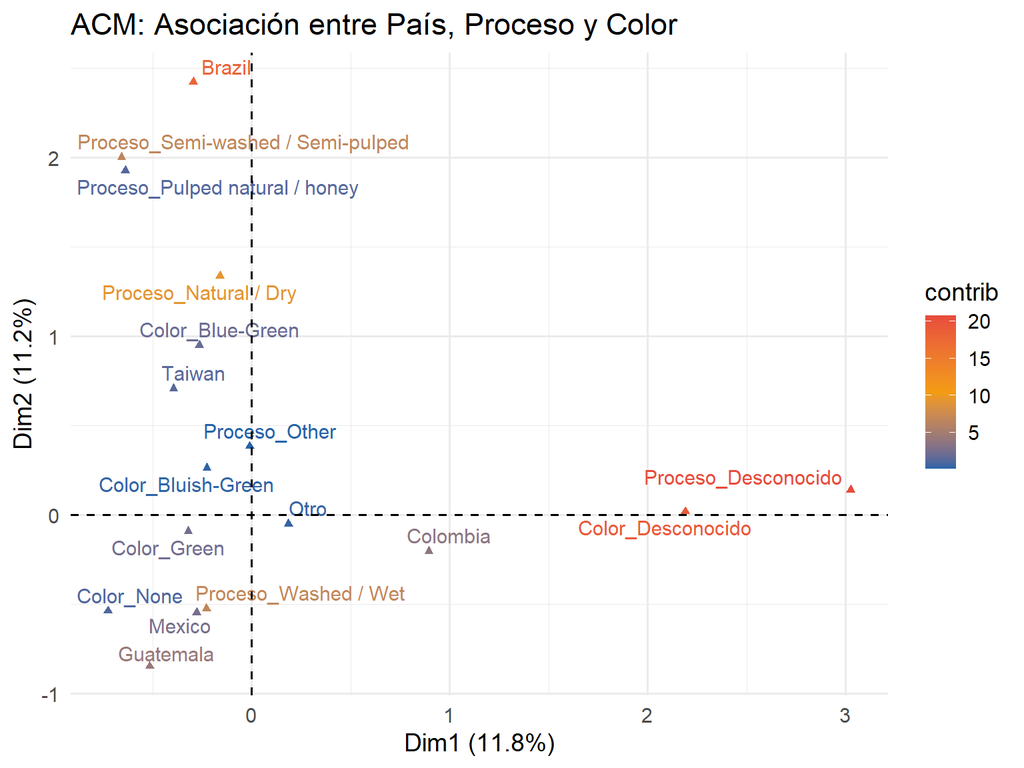

```r
factoextra::fviz_mca_var(
  res_mca,
  repel = TRUE,
  col.var = "contrib",
  gradient.cols = c("#2563a8", "#f39c12", "#e74c3c"),
  title = "ACM: Asociación entre País, Proceso y Color"
) +
  ggplot2::theme_minimal(base_size = 14)
```

**Cómo se lee.** Cada punto es una categoría y su color indica cuánto contribuye a los ejes (más rojo, más contribuye). Categorías cercanas aparecen juntas en muchos lotes: por ejemplo, un proceso y un país que se encuentran cerca indican que ese proceso es característico de ese país. Es una **asociación entre categorías, no una relación causal**, y el mapa solo representa el 23,0 % de la inercia.

# Conclusiones

1. **Análisis factorial:** las 11 variables continuas son aptas para factorizar (KMO 0,94; Bartlett significativo) y se resumen en 3 factores que explican el 66,9 % de la varianza.
2. **Correspondencias simple:** proceso y país están asociados (chi² significativa); la combinación más sobrerrepresentada es Natural / Dry en Brazil.
3. **Correspondencias múltiple:** al sumar el color del grano, las dos primeras dimensiones explican el 23,0 % de la inercia. La **dimensión 1** separa los lotes con proceso y color sin registrar; la **dimensión 2** contrapone Brasil y el proceso natural al proceso lavado (Guatemala, México). El mapa describe asociaciones entre categorías y debe leerse con prudencia.
4. **Alcance:** estas técnicas muestran asociaciones, no causas, y no usan los puntajes sensoriales en el ACM.